# Ujian Akhir Semester - Data Mining

### Nama : Rypaldho Hutagaol

### NIM : 230411100076

### Dataset : Statlog (Heart) Data Set

### Sumber : https://archive.ics.uci.edu/dataset/145/statlog+heart

## Persiapan Awal (mengimpor library yang dibutuhkan)

```python
import pandas as pd
import numpy as np
import matplotlib.pyplot as plt
import seaborn as sns
import pickle

from sklearn.model_selection import train_test_split
from sklearn.preprocessing import StandardScaler
from sklearn.linear_model import LogisticRegression
from sklearn.neighbors import KNeighborsClassifier
from sklearn.svm import SVC
from sklearn.ensemble import RandomForestClassifier
from sklearn.metrics import accuracy_score, classification_report, confusion_matrix

# Mengatur agar semua kolom ditampilkan saat menggunakan print(df)
pd.set_option('display.max_columns', None)

# Mengatur style plot seaborn
sns.set_style('whitegrid')
```

## Memuat data & Data Understanding

### 1. Memuat data

Langkah pertama adalah memuat data ke dalam lingkungan kerja. Pada kasus ini, data dari file .dat tidak memiliki header (nama kolom) dan pemisahnya adalah spasi, bukan koma. Oleh karena itu, kita perlu secara eksplisit mendefinisikan nama-nama kolom berdasarkan dokumentasi (heart.doc) dan mengatur separator=' '.

```python
# Tentukan nama kolom berdasarkan file heart.doc
column_names = [
    'age', 'sex', 'cp', 'trestbps', 'chol', 'fbs', 'restecg',
    'thalach', 'exang', 'oldpeak', 'slope', 'ca', 'thal', 'target'
]

# Muat data dari URL
url = 'https://archive.ics.uci.edu/ml/machine-learning-databases/statlog/heart/heart.dat'
df = pd.read_csv(url, sep=' ', header=None, names=column_names)

print("Lima baris pertama dari dataset:")
print(df.head())
print("\nInformasi dasar dataset:")
df.info()
```

```
Lima baris pertama dari dataset:
    age  sex   cp  trestbps   chol  fbs  restecg  thalach  exang  oldpeak  \
0  70.0  1.0  4.0     130.0  322.0  0.0      2.0    109.0    0.0      2.4
1  67.0  0.0  3.0     115.0  564.0  0.0      2.0    160.0    0.0      1.6
2  57.0  1.0  2.0     124.0  261.0  0.0      0.0    141.0    0.0      0.3
3  64.0  1.0  4.0     128.0  263.0  0.0      0.0    105.0    1.0      0.2
4  74.0  0.0  2.0     120.0  269.0  0.0      2.0    121.0    1.0      0.2

   slope   ca  thal  target
0    2.0  3.0   3.0       2
1    2.0  0.0   7.0       1
2    1.0  0.0   7.0       2
3    2.0  1.0   7.0       1
4    1.0  1.0   3.0       1

Informasi dasar dataset:
<class 'pandas.core.frame.DataFrame'>
RangeIndex: 270 entries, 0 to 269
Data columns (total 14 columns):
 #   Column    Non-Null Count  Dtype
---  ------    --------------  -----
 0   age       270 non-null    float64
 1   sex       270 non-null    float64
 2   cp        270 non-null    float64
 3   trestbps  270 non-null    float64
 4   chol      270 non-null    float64
 5   fbs       270 non-null    float64
 6   restecg   270 non-null    float64
 7   thalach   270 non-null    float64
 8   exang     270 non-null    float64
 9   oldpeak   270 non-null    float64
 10  slope     270 non-null    float64
 11  ca        270 non-null    float64
 12  thal      270 non-null    float64
 13  target    270 non-null    int64
dtypes: float64(13), int64(1)
memory usage: 29.7 KB
```

### Melihat Informasi Dasar (df.head(), df.info()):

- df.head() digunakan untuk melihat 5 baris pertama data. Ini memberikan kita gambaran visual tentang bagaimana data tersusun.
- df.info() memberikan ringkasan teknis: jumlah baris, jumlah kolom, nama setiap kolom, jumlah data non-null (untuk cek missing values), dan tipe data setiap kolom (int64, float64). Dari sini kita bisa mengidentifikasi mana fitur numerik dan mana yang kategorikal.

### 2. Data Understanding

Memahami setiap fitur yang ada dalam dataset

```python
print("\n" + "="*80)
print("KAMUS DATA (DATA DICTIONARY)".center(80))
print("="*80)
print("""
- age: Umur pasien (Numerik)
- sex: Jenis kelamin (1 = Laki-laki; 0 = Perempuan) (Kategorikal)
- cp: Tipe nyeri dada (chest pain type) (Kategorikal)
    - 1: typical angina
    - 2: atypical angina
    - 3: non-anginal pain
    - 4: asymptomatic
- trestbps: Tekanan darah saat istirahat (resting blood pressure) (dalam mm Hg) (Numerik)
- chol: Kolesterol serum (serum cholestoral) (dalam mg/dl) (Numerik)
- fbs: Gula darah puasa > 120 mg/dl (fasting blood sugar) (Kategorikal)
    - 1 = True (Benar)
    - 0 = False (Salah)
- restecg: Hasil elektrokardiogram saat istirahat (resting electrocardiographic results) (Kategorikal)
    - 0: normal
    - 1: memiliki kelainan gelombang ST-T
    - 2: menunjukkan kemungkinan hipertrofi ventrikel kiri
- thalach: Detak jantung maksimum yang tercapai (maximum heart rate achieved) (Numerik)
- exang: Nyeri dada akibat olahraga (exercise induced angina) (Kategorikal)
    - 1 = Ya
    - 0 = Tidak
- oldpeak: Depresi ST yang diinduksi oleh olahraga relatif terhadap istirahat (ST depression induced by exercise relative to rest) (Numerik)
- slope: Kemiringan puncak segmen ST saat olahraga (the slope of the peak exercise ST segment) (Kategorikal)
    - 1: upsloping
    - 2: flat
    - 3: downsloping
- ca: Jumlah pembuluh darah utama (0-3) yang diwarnai oleh fluoroskopi (number of major vessels) (Kategorikal)
- thal: Kelainan thalasemia (Kategorikal)
    - 3: normal
    - 6: fixed defect
    - 7: reversable defect
- target: Diagnosis penyakit jantung (Variabel Target) (Kategorikal)
    - 1: Sehat (tidak ada penyakit jantung)
    - 2: Sakit (ada penyakit jantung)
""")
print("="*80)
```

```
================================================================================
                          KAMUS DATA (DATA DICTIONARY)
================================================================================

- age: Umur pasien (Numerik)
- sex: Jenis kelamin (1 = Laki-laki; 0 = Perempuan) (Kategorikal)
- cp: Tipe nyeri dada (chest pain type) (Kategorikal)
    - 1: typical angina
    - 2: atypical angina
    - 3: non-anginal pain
    - 4: asymptomatic
- trestbps: Tekanan darah saat istirahat (resting blood pressure) (dalam mm Hg) (Numerik)
- chol: Kolesterol serum (serum cholestoral) (dalam mg/dl) (Numerik)
- fbs: Gula darah puasa > 120 mg/dl (fasting blood sugar) (Kategorikal)
    - 1 = True (Benar)
    - 0 = False (Salah)
- restecg: Hasil elektrokardiogram saat istirahat (resting electrocardiographic results) (Kategorikal)
    - 0: normal
    - 1: memiliki kelainan gelombang ST-T
    - 2: menunjukkan kemungkinan hipertrofi ventrikel kiri
- thalach: Detak jantung maksimum yang tercapai (maximum heart rate achieved) (Numerik)
- exang: Nyeri dada akibat olahraga (exercise induced angina) (Kategorikal)
    - 1 = Ya
    - 0 = Tidak
- oldpeak: Depresi ST yang diinduksi oleh olahraga relatif terhadap istirahat (ST depression induced by exercise relative to rest) (Numerik)
- slope: Kemiringan puncak segmen ST saat olahraga (the slope of the peak exercise ST segment) (Kategorikal)
    - 1: upsloping
    - 2: flat
    - 3: downsloping
- ca: Jumlah pembuluh darah utama (0-3) yang diwarnai oleh fluoroskopi (number of major vessels) (Kategorikal)
- thal: Kelainan thalasemia (Kategorikal)
    - 3: normal
    - 6: fixed defect
    - 7: reversable defect
- target: Diagnosis penyakit jantung (Variabel Target) (Kategorikal)
    - 1: Sehat (tidak ada penyakit jantung)
    - 2: Sakit (ada penyakit jantung)

================================================================================
```

### Membuat Kamus Data (Data Dictionary):

Ini adalah langkah terpenting dalam data understanding. Kita menerjemahkan nama-nama fitur yang terkadang samar (seperti cp, thalach) menjadi deskripsi yang jelas dan dapat dimengerti manusia. Misalnya:

- trestbps: Diterjemahkan sebagai "Tekanan darah saat istirahat".
- chol: Diterjemahkan sebagai "Kadar kolesterol serum".
- target: Diterjemahkan sebagai "Variabel target yang menunjukkan keberadaan penyakit jantung".

## Data preporcessing & exploratory data analysis

### 1. Mengubah Variabel Target

Mengubah nilai pada kolom target agar lebih standar untuk klasifikasi biner:

- (tidak ada penyakit) -> 0
- (ada penyakit) -> 1

Nilai target asli adalah 1 (sehat) dan 2 (sakit). Ini diubah menjadi 0 (sehat) dan 1 (sakit). Ini adalah praktik standar dalam klasifikasi biner karena banyak algoritma dan metrik evaluasi di Python (Scikit-learn) bekerja lebih baik dengan format 0 dan 1.

```python
df['target'] = df['target'].replace({1: 0, 2: 1})
print("\nDistribusi kelas target setelah diubah:")
print(df['target'].value_counts())
```

```
Distribusi kelas target setelah diubah:
target
0    150
1    120
Name: count, dtype: int64
```

### 2. Exploratory Data Analysis (EDA)

### Statistik Deskriptif

Memberikan ringkasan statistik (rata-rata, standar deviasi, min, max, kuartil) untuk fitur numerik. Dari sini kita bisa melihat rentang nilai setiap fitur.

```python
print("\nStatistik Deskriptif untuk Fitur Numerik:")
print(df[['age', 'trestbps', 'chol', 'thalach', 'oldpeak']].describe())
```

```
Statistik Deskriptif untuk Fitur Numerik:
              age    trestbps        chol     thalach    oldpeak
count  270.000000  270.000000  270.000000  270.000000  270.00000
mean    54.433333  131.344444  249.659259  149.677778    1.05000
std      9.109067   17.861608   51.686237   23.165717    1.14521
min     29.000000   94.000000  126.000000   71.000000    0.00000
25%     48.000000  120.000000  213.000000  133.000000    0.00000
50%     55.000000  130.000000  245.000000  153.500000    0.80000
75%     61.000000  140.000000  280.000000  166.000000    1.60000
max     77.000000  200.000000  564.000000  202.000000    6.20000
```

### Pengecekan Missing Values

```python
print("\nJumlah Missing Values per Kolom:")
print(df.isnull().sum())
print("--> Dataset ini bersih dan tidak memiliki missing values.")
```

```
Jumlah Missing Values per Kolom:
age         0
sex         0
cp          0
trestbps    0
chol        0
fbs         0
restecg     0
thalach     0
exang       0
oldpeak     0
slope       0
ca          0
thal        0
target      0
dtype: int64
--> Dataset ini bersih dan tidak memiliki missing values.
```

## Visualisasi Data

### Distribusi Kelas Target

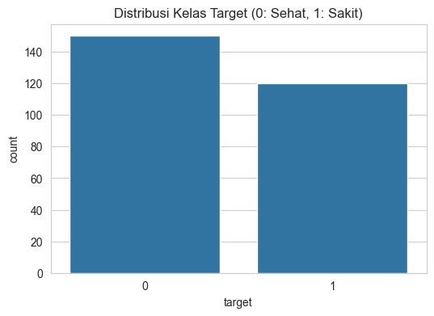

```python
plt.figure(figsize=(6, 4))
sns.countplot(x='target', data=df)
plt.title('Distribusi Kelas Target (0: Sehat, 1: Sakit)')
plt.show()
```

### Distribusi Fitur Numerik

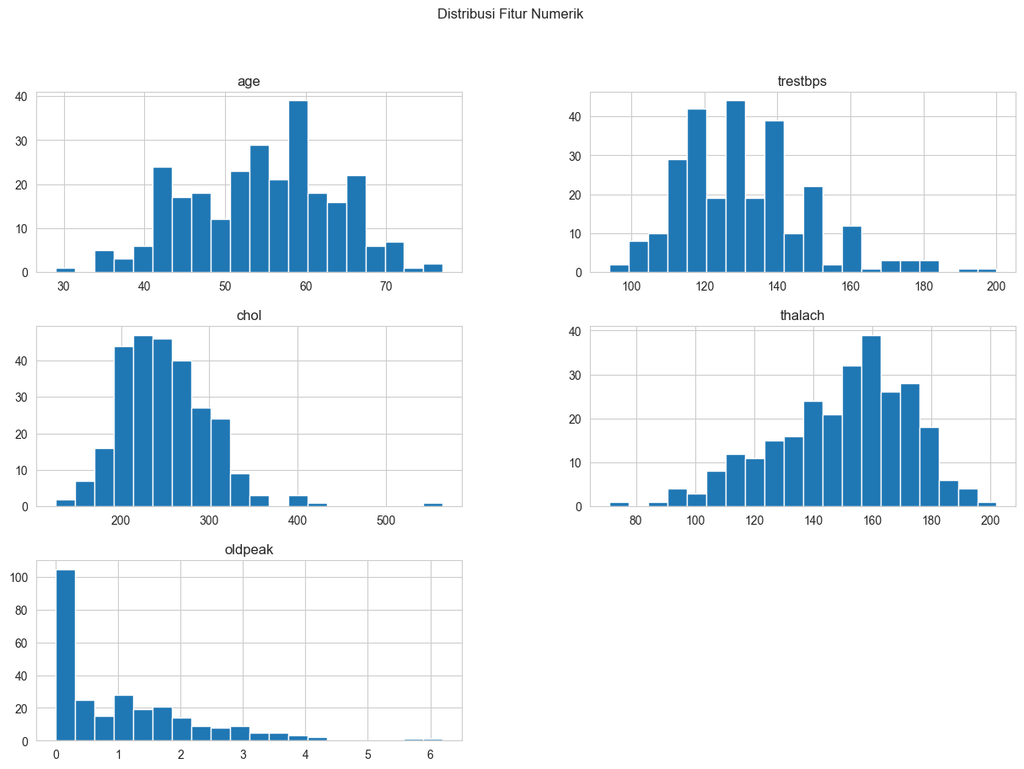

```python
numerical_features = ['age', 'trestbps', 'chol', 'thalach', 'oldpeak']
df[numerical_features].hist(bins=20, figsize=(15, 10))
plt.suptitle('Distribusi Fitur Numerik')
plt.show()
```

### Distribusi Fitur Kategorikal

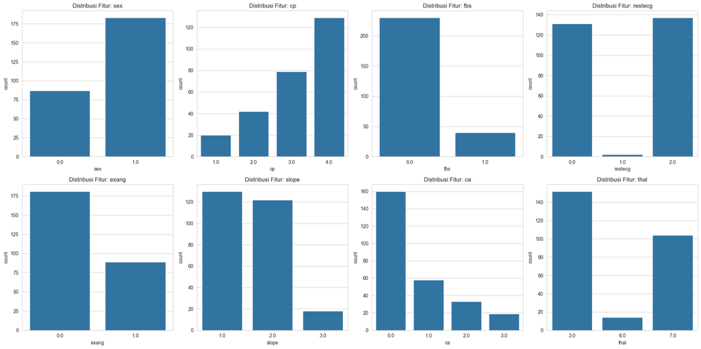

```python
categorical_features = ['sex', 'cp', 'fbs', 'restecg', 'exang', 'slope', 'ca', 'thal']
fig, axes = plt.subplots(2, 4, figsize=(20, 10))
axes = axes.flatten() # Meratakan array axes agar mudah di-loop

for i, col in enumerate(categorical_features):
    sns.countplot(x=col, data=df, ax=axes[i])
    axes[i].set_title(f'Distribusi Fitur: {col}')
plt.tight_layout()
plt.show()
```

### Heatmap Korelasi

Ini adalah visualisasi yang sangat kuat untuk melihat hubungan linear antar fitur. Warna yang lebih terang atau lebih gelap menunjukkan korelasi yang lebih kuat. Ini membantu kita melihat fitur mana yang mungkin sangat berpengaruh terhadap target.

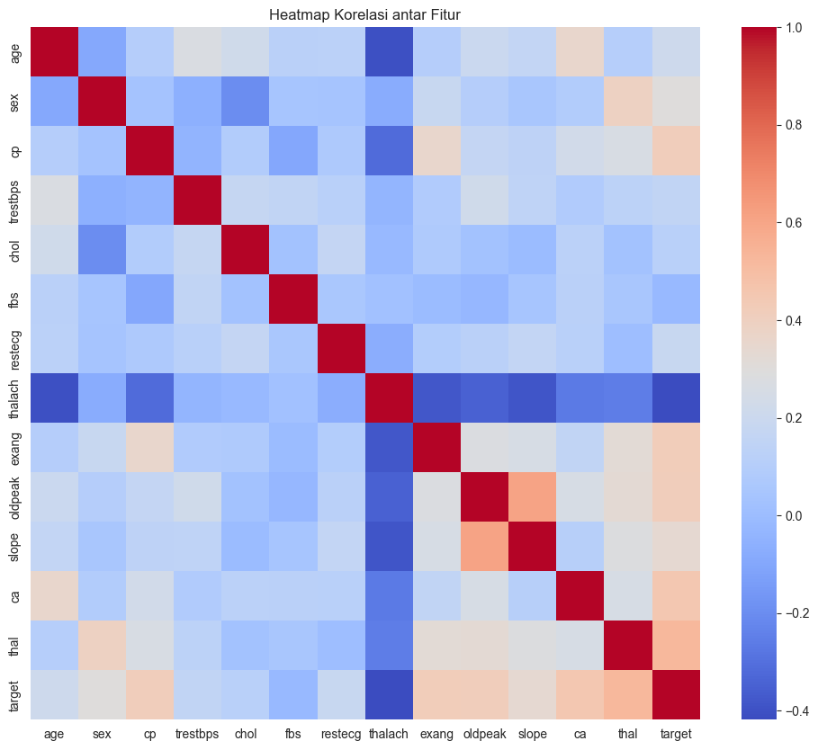

```python
plt.figure(figsize=(12, 10))
correlation_matrix = df.corr()
sns.heatmap(correlation_matrix, annot=False, cmap='coolwarm')
plt.title('Heatmap Korelasi antar Fitur')
plt.show()
```

## 3. Preprocessing untuk Modeling

### Memisahkan Fitur (X) dan Target (y)

```python
X = df.drop('target', axis=1)
y = df['target']
```

### Membagi Data menjadi Data Latih dan Data Uji (80:20)

```python
X_train, X_test, y_train, y_test = train_test_split(X, y, test_size=0.2, random_state=42, stratify=y)
print(f"\nUkuran Data Latih (X_train): {X_train.shape}")
print(f"Ukuran Data Uji (X_test): {X_test.shape}")
```

```
Ukuran Data Latih (X_train): (216, 13)
Ukuran Data Uji (X_test): (54, 13)
```

### Feature Scaling (StandardScaler):

Fitur-fitur numerik memiliki skala yang sangat berbeda (misal: age puluhan, chol ratusan). Algoritma seperti SVM dan KNN sangat sensitif terhadap skala ini. Fitur dengan skala besar dapat mendominasi proses pembelajaran. StandardScaler mengubah semua fitur numerik sehingga memiliki rata-rata 0 dan standar deviasi 1, menempatkan mereka pada skala yang sebanding.

```python
# Scaling hanya dilakukan pada fitur numerik untuk menyamakan skala nilainya.
scaler = StandardScaler()

# Fit dan transform pada data latih
X_train[numerical_features] = scaler.fit_transform(X_train[numerical_features])

# Hanya transform pada data uji (menggunakan scaler yang sudah di-fit dari data latih)
X_test[numerical_features] = scaler.transform(X_test[numerical_features])

print("\nLima baris pertama dari data latih setelah di-scaling:")
print(X_train.head())
```

```
Lima baris pertama dari data latih setelah di-scaling:
          age  sex   cp  trestbps      chol  fbs  restecg   thalach  exang  \
78  -1.336180  0.0  3.0 -0.637952 -0.762981  0.0      0.0  1.007469    0.0
121 -0.039034  1.0  4.0 -0.522736  0.732412  0.0      2.0 -1.551103    1.0
27  -0.363321  0.0  3.0 -0.637952  0.907198  0.0      2.0  0.289273    0.0
198  1.582397  0.0  1.0  0.514202 -0.180361  0.0      0.0  0.019950    0.0
218 -0.039034  1.0  3.0 -0.637952  0.188632  0.0      2.0 -0.159599    0.0

      oldpeak  slope   ca  thal
78  -0.939241    2.0  0.0   3.0
121  1.937160    2.0  2.0   3.0
27  -0.399916    1.0  0.0   3.0
198  0.678734    1.0  2.0   3.0
218 -0.579691    2.0  0.0   7.0
```

## Modeling

Tahap ini adalah inti dari machine learning. Tujuannya adalah untuk melatih berbagai algoritma klasifikasi menggunakan data latih yang sudah bersih. Setiap algoritma akan "mempelajari" pola-pola yang membedakan antara pasien yang sehat dan yang sakit.

#### Melatih beberapa model klasifikasi untuk dibandingkan performanya.

```python
models = {
    "Logistic Regression": LogisticRegression(random_state=42),
    "K-Nearest Neighbors": KNeighborsClassifier(),
    "Support Vector Machine": SVC(random_state=42),
    "Random Forest": RandomForestClassifier(random_state=42)
}

# Melatih setiap model
for name, model in models.items():
    print(f"Melatih model {name}...")
    model.fit(X_train, y_train)

print("\nSemua model telah berhasil dilatih.")
```

```
Melatih model Logistic Regression...
Melatih model K-Nearest Neighbors...
Melatih model Support Vector Machine...
Melatih model Random Forest...

Semua model telah berhasil dilatih.
```

Kita tidak tahu algoritma mana yang akan berkinerja terbaik untuk dataset ini. Oleh karena itu, kita memilih beberapa model yang populer dan memiliki pendekatan berbeda:

- Logistic Regression: Model statistik yang sederhana dan cepat, baik sebagai baseline.
- K-Nearest Neighbors (KNN): Model berbasis jarak, mengklasifikasikan data baru berdasarkan "tetangga" terdekatnya.
- Support Vector Machine (SVM): Model yang kuat, bekerja dengan mencari "jalan" atau hyperplane terbaik yang memisahkan dua kelas.
- Random Forest: Model ensemble yang sangat kuat, terdiri dari banyak "pohon keputusan" dan mengambil keputusan berdasarkan suara mayoritas. Biasanya memberikan akurasi yang tinggi.

### Evaluasi Model

Setelah model dilatih, kita perlu mengukur seberapa baik performa model tersebut. Evaluasi dilakukan pada data uji, yaitu data yang tidak digunakan selama pelatihan, untuk mendapatkan penilaian yang objektif.

```
==================================================
       EVALUASI MODEL: Logistic Regression
==================================================
Akurasi: 0.8519

Classification Report:
              precision    recall  f1-score   support

           0       0.92      0.80      0.86        30
           1       0.79      0.92      0.85        24

    accuracy                           0.85        54
   macro avg       0.85      0.86      0.85        54
weighted avg       0.86      0.85      0.85        54
```

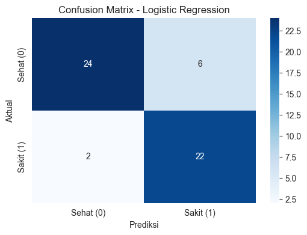

```
==================================================
       EVALUASI MODEL: K-Nearest Neighbors
==================================================
Akurasi: 0.8148

Classification Report:
              precision    recall  f1-score   support

           0       0.86      0.80      0.83        30
           1       0.77      0.83      0.80        24

    accuracy                           0.81        54
   macro avg       0.81      0.82      0.81        54
weighted avg       0.82      0.81      0.82        54
```

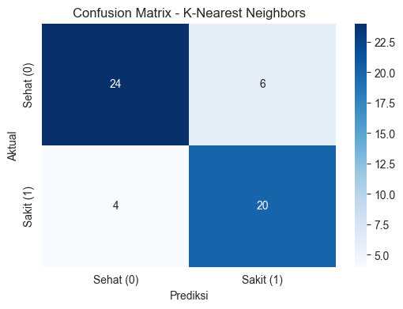

```
==================================================
      EVALUASI MODEL: Support Vector Machine
==================================================
Akurasi: 0.8519

Classification Report:
              precision    recall  f1-score   support

           0       0.89      0.83      0.86        30
           1       0.81      0.88      0.84        24

    accuracy                           0.85        54
   macro avg       0.85      0.85      0.85        54
weighted avg       0.86      0.85      0.85        54
```

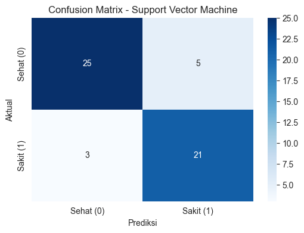

```
==================================================
          EVALUASI MODEL: Random Forest
==================================================
Akurasi: 0.8148

Classification Report:
              precision    recall  f1-score   support

           0       0.86      0.80      0.83        30
           1       0.77      0.83      0.80        24

    accuracy                           0.81        54
   macro avg       0.81      0.82      0.81        54
weighted avg       0.82      0.81      0.82        54
```

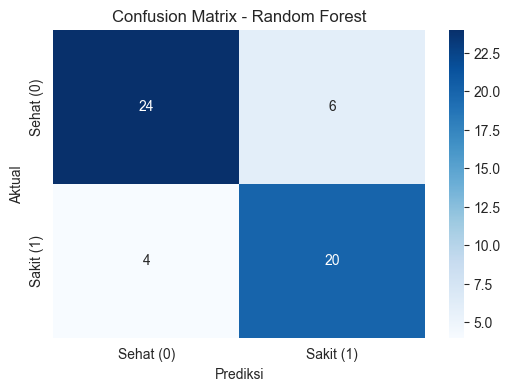

```
================================================================================
                              KESIMPULAN EVALUASI

Model dengan performa terbaik adalah 'Logistic Regression' dengan akurasi 0.8519.
Model ini akan disimpan untuk proses deployment.
================================================================================
```

```python
# Mengevaluasi performa setiap model pada data uji.

best_model_name = ""
best_accuracy = 0.0

for name, model in models.items():
    # Membuat prediksi
    y_pred = model.predict(X_test)

    # Menghitung akurasi
    accuracy = accuracy_score(y_test, y_pred)

    print("\n" + "="*50)
    print(f"EVALUASI MODEL: {name}".center(50))
    print("="*50)
    print(f"Akurasi: {accuracy:.4f}")

    # Menampilkan Classification Report
    print("\nClassification Report:")
    print(classification_report(y_test, y_pred))

    # Menampilkan Confusion Matrix
    cm = confusion_matrix(y_test, y_pred)
    plt.figure(figsize=(6, 4))
    sns.heatmap(cm, annot=True, fmt='d', cmap='Blues',
                xticklabels=['Sehat (0)', 'Sakit (1)'],
                yticklabels=['Sehat (0)', 'Sakit (1)'])
    plt.xlabel('Prediksi')
    plt.ylabel('Aktual')
    plt.title(f'Confusion Matrix - {name}')
    plt.show()

    # Memperbarui model terbaik jika akurasi saat ini lebih tinggi
    if accuracy > best_accuracy:
        best_accuracy = accuracy
        best_model_name = name

print("\n" + "="*80)
print("KESIMPULAN EVALUASI".center(80))
print(f"\nModel dengan performa terbaik adalah '{best_model_name}' dengan akurasi {best_accuracy:.4f}.")
print("Model ini akan disimpan untuk proses deployment.")
print("="*80)
```

1. Accuracy: Metrik paling sederhana, yaitu persentase tebakan yang benar dari total tebakan. Baik untuk gambaran umum, tetapi tidak cukup.
2. Confusion Matrix: Ini adalah tabel yang merinci performa model. Sangat penting untuk kasus medis.
   - True Positive (TP): Prediksi: Sakit, Aktual: Sakit. (Benar)
   - True Negative (TN): Prediksi: Sehat, Aktual: Sehat. (Benar)
   - False Positive (FP): Prediksi: Sakit, Aktual: Sehat. (Error Tipe I)
   - False Negative (FN): Prediksi: Sehat, Aktual: Sakit. (Error Tipe II) -> Ini adalah error yang paling berbahaya dalam kasus medis, karena pasien sakit dianggap sehat.
3. Classification Report (Precision, Recall, F1-Score):
   - Precision: Dari semua yang kita prediksi "Sakit", berapa persen yang benar-benar sakit? (Fokus pada meminimalkan FP).
   - Recall (Sensitivity): Dari semua pasien yang sebenarnya "Sakit", berapa persen yang berhasil kita identifikasi? (Fokus pada meminimalkan FN). Untuk diagnosis penyakit, Recall sering kali menjadi metrik yang lebih penting.
   - F1-Score: Rata-rata harmonik dari Precision dan Recall. Memberikan skor tunggal yang menyeimbangkan keduanya.

Berdasarkan metrik-metrik ini, kita dapat membandingkan semua model secara objektif dan memilih model terbaik (dalam kasus ini, yang memiliki akurasi dan metrik lain yang paling seimbang dan tinggi) untuk disimpan dan digunakan pada tahap deployment.

## Deployment Model

#### Menyimpan model terbaik ke dalam sebuah file untuk digunakan nanti.

### 1. Menyimpan model Terbaik

```python
best_model = models[best_model_name]
filename = 'model_penyakit_jantung.pkl'

with open(filename, 'wb') as file:
    pickle.dump(best_model, file)

print(f"\nModel terbaik ({best_model_name}) telah disimpan ke dalam file '{filename}'.")
```

```
Model terbaik (Logistic Regression) telah disimpan ke dalam file 'model_penyakit_jantung.pkl'.
```

### 2 Menyimpan Scaler

#### Scaler juga harus disimpan agar data baru bisa diproses dengan cara yang sama.

```python
scaler_filename = 'scaler.pkl'
with open(scaler_filename, 'wb') as file:
    pickle.dump(scaler, file)
print(f"Scaler telah disimpan ke dalam file '{scaler_filename}'.")
```

```
Scaler telah disimpan ke dalam file 'scaler.pkl'.
```

### 3 Simulasi Penggunaan Model (Deployment)

#### Membuat fungsi untuk mensimulasikan bagaimana model akan digunakan pada data baru.

```python
def predict_heart_disease(data_baru):
    """
    Fungsi untuk memprediksi penyakit jantung berdasarkan data baru.

    Args:
    data_baru (dict): Sebuah dictionary berisi data pasien baru.

    Returns:
    str: Hasil prediksi (Sakit atau Sehat).
    """
    # Memuat model dan scaler yang sudah disimpan
    try:
        with open('model_penyakit_jantung.pkl', 'rb') as file:
            loaded_model = pickle.load(file)
        with open('scaler.pkl', 'rb') as file:
            loaded_scaler = pickle.load(file)
    except FileNotFoundError:
        return "Error: File model atau scaler tidak ditemukan. Harap latih dan simpan model terlebih dahulu."

    # Mengubah data dictionary menjadi DataFrame
    df_baru = pd.DataFrame([data_baru])

    # Memastikan urutan kolom sama dengan saat training
    df_baru = df_baru[X_train.columns]

    # Melakukan scaling pada fitur numerik
    df_baru[numerical_features] = loaded_scaler.transform(df_baru[numerical_features])

    # Membuat prediksi
    prediksi = loaded_model.predict(df_baru)
    probabilitas = loaded_model.predict_proba(df_baru)

    # Menginterpretasikan hasil
    if prediksi[0] == 1:
        hasil = "Pasien diprediksi MEMILIKI PENYAKIT JANTUNG."
    else:
        hasil = "Pasien diprediksi SEHAT."

    return f"{hasil} (Probabilitas: {probabilitas[0][prediksi[0]]:.2f})"
```

### Contoh Penggunaan Fungsi Deployment

#### Contoh 1: Data pasien yang gejalanya mengarah ke penyakit jantung

```python
pasien_baru_1 = {
    'age': 57,
    'sex': 1,
    'cp': 4,
    'trestbps': 150,
    'chol': 276,
    'fbs': 0,
    'restecg': 2,
    'thalach': 112,
    'exang': 1,
    'oldpeak': 0.6,
    'slope': 2,
    'ca': 1,
    'thal': 7
}
```

### Contoh 2: Data pasien yang gejalanya terlihat sehat

```python
pasien_baru_2 = {
    'age': 35,
    'sex': 0,
    'cp': 1,
    'trestbps': 120,
    'chol': 180,
    'fbs': 0,
    'restecg': 0,
    'thalach': 180,
    'exang': 0,
    'oldpeak': 0,
    'slope': 1,
    'ca': 0,
    'thal': 3
}

print("\n" + "="*80)
print("SIMULASI DEPLOYMENT".center(80))
print("="*80)
print("\nMemprediksi data pasien baru 1...")
hasil_prediksi_1 = predict_heart_disease(pasien_baru_1)
print(f"Hasil Prediksi 1: {hasil_prediksi_1}")

print("\nMemprediksi data pasien baru 2...")
hasil_prediksi_2 = predict_heart_disease(pasien_baru_2)
print(f"Hasil Prediksi 2: {hasil_prediksi_2}")
print("\n" + "="*80)
print("PROSES ANALISIS SELESAI".center(80))
print("="*80)
```

```
================================================================================
                              SIMULASI DEPLOYMENT
================================================================================

Memprediksi data pasien baru 1...
Hasil Prediksi 1: Pasien diprediksi MEMILIKI PENYAKIT JANTUNG. (Probabilitas: 0.98)

Memprediksi data pasien baru 2...
Hasil Prediksi 2: Pasien diprediksi SEHAT. (Probabilitas: 1.00)

================================================================================
                            PROSES ANALISIS SELESAI
================================================================================
```